# Exploratory 1: Daughters and Grand-daughters

I thought I’d start off by trying to calculate some of the direct descendant measures mentioned in the 1974 Goodman paper. It won’t be a direct replication because I’ll use the WPP life table data. TL;DR: seems to work okay.

## Stable population formulas for direct descendants

The first set of integrals presented in the paper relate to the number of daughters / grand-daughters / great-grand-daughters alive at a particular time. The integrals are recursive in nature and account for age-specific fertility schedules and the survivorship of women to particular ages. The (expected) number of daughters alive at time $t$ to a women of age $a$ is

$$\int_{\alpha}^a l_{a-x} m_x dx$$

In words: the number of births to a women of age $x$ is m_x, the proportion of girls surviving to age $a-x$ (i.e. surviving to when the mother is age $a$) is $l_{a-x}$, and then sum up over all candidate ages $x$.

Using the same logic, the expression for grand-daughters is

$$\int_{\alpha}^a \left[\int_{\alpha}^{a-x}l_y m_y l_{a-x-y}dy \right] m_x dx$$

Given these are continuous functions, how are they calculated in a practical sense? We have data in five-year intervals. Use the fact that $_5L_x = \int_x^{x+5} l_x dx$ and assume $_5F_x = m_x$. Then the first integral can be approximated as

$$\sum_{\alpha = 15}^{a} {_5L_{a-x}}\cdot {_5F_x}$$

For the double integral, following pages 25 and 26 of the paper, write the inner integral as a function of $x$:

$$I(x) = \int_{\alpha}^{a-x}l_y m_y l_{a-x-y}dy$$

For a given $x$ and $a$ this is approximated as

$$\sum_{15}^{a-x} {_5L_{z}}\cdot {_5F_z} \cdot {_5L_{a-x-z}}$$

The whole of the double integral expression is estimated as

$$\sum_{15}^{45}I(\bar{z}) {_5F_z}$$
where $I(\bar{z})$ is approximated as $0.5(I(z) + I(z+5))$.

## Calculations on WPP data for USA, 1965

Try out some of these measures using data produced as part of the UN World Population prospects. They have life table and fertility estimates for all countries over a long time period avaialable [here](https://esa.un.org/unpd/wpp/Download/). All I did was download the files and save as a csv without the UN-type header.

### Read in the data

Read in the life table data:

```r
library(tidyverse)
library(here)
lt <- read_csv(here("data", "wpp_lt.csv"))
head(lt)
```

| Index | Variant | Region, subregion, country or area * | Notes | Country code | Period | Age (x) | Age interval (n) | Central death rate m(x,n) | Probability of dying q(x,n) | Probability of surviving p(x,n) | Number of survivors l(x) | Number of deaths d(x,n) | Number of person-years lived L(x,n) | Survival ratio S(x,n) | Person-years lived T(x) | Expectation of life e(x) | Average number of years lived a(x,n) |
| --- | --- | --- | --- | --- | --- | --- | --- | --- | --- | --- | --- | --- | --- | --- | --- | --- | --- |
| 1 | Estimates | WORLD | NA | 900 | 1950-1955 | 0 | 1 | 0.146920751 | 0.134113148 | 0.865886852 | 100000.00 | 13411.315 | 91282.65 | 0.838845516 | 4850370 | 48.50370 | 0.350000 |
| 2 | Estimates | WORLD | NA | 900 | 1950-1955 | 1 | 4 | 0.023079364 | 0.087462527 | 0.912537473 | 86588.69 | 7573.265 | 328140.11 | 0.925866321 | 4759087 | 54.96200 | 1.594878 |
| 3 | Estimates | WORLD | NA | 900 | 1950-1955 | 5 | 5 | 0.006312965 | 0.031025715 | 0.968974285 | 79015.42 | 2451.510 | 388329.41 | 0.976101581 | 4430947 | 56.07699 | 2.247536 |
| 4 | Estimates | WORLD | NA | 900 | 1950-1955 | 10 | 5 | 0.003622467 | 0.017933936 | 0.982066064 | 76563.91 | 1373.092 | 379048.95 | 0.981574975 | 4042618 | 52.80057 | 2.253933 |
| 5 | Estimates | WORLD | NA | 900 | 1950-1955 | 15 | 5 | 0.004302546 | 0.021290188 | 0.978709812 | 75190.82 | 1600.827 | 372064.96 | 0.976411916 | 3663569 | 48.72362 | 2.570550 |
| 6 | Estimates | WORLD | NA | 900 | 1950-1955 | 20 | 5 | 0.005250973 | 0.02592226 | 0.97407774 | 73589.99 | 1907.619 | 363288.66 | 0.972283386 | 3291504 | 44.72760 | 2.556485 |

Read in the fertility data

```r
fx <- read_csv(here("data", "wpp_fx.csv"))
head(fx)
```

| Index | Variant | Region, subregion, country or area * | Notes | Country code | Period | 15-19 | 20-24 | 25-29 | 30-34 | 35-39 | 40-44 | 45-49 |
| --- | --- | --- | --- | --- | --- | --- | --- | --- | --- | --- | --- | --- |
| 1 | Estimates | WORLD | NA | 900 | 1950-1955 | 86.42387 | 234.4593 | 249.8475 | 199.7709 | 139.27886 | 65.48701 | 15.81914 |
| 2 | Estimates | WORLD | NA | 900 | 1955-1960 | 84.96300 | 235.1675 | 248.4824 | 194.9832 | 134.85578 | 63.71999 | 14.86159 |
| 3 | Estimates | WORLD | NA | 900 | 1960-1965 | 85.01729 | 245.8466 | 257.6188 | 202.9554 | 137.46793 | 63.41302 | 14.52106 |
| 4 | Estimates | WORLD | NA | 900 | 1965-1970 | 80.28883 | 243.2766 | 257.5352 | 198.8790 | 130.94950 | 59.68123 | 13.97844 |
| 5 | Estimates | WORLD | NA | 900 | 1970-1975 | 74.32146 | 226.3936 | 240.6507 | 175.9295 | 112.46599 | 50.68872 | 12.37117 |
| 6 | Estimates | WORLD | NA | 900 | 1975-1980 | 70.45071 | 208.5239 | 209.9631 | 146.3939 | 87.37333 | 39.56736 | 10.79423 |

Start off by looking at the US in the period 1965-1970, in the hope that our estimates are somewhat in the ballpark of Goodman et als. Join the two datasets and tidy up names, etc.

```r
# mortality df
df_mort <- lt %>%
  # tidy up names
  rename(year = Period,
         region = `Region, subregion, country or area *`,
         age = `Age (x)`,
         Lx = `Number of person-years lived L(x,n)`) %>%
  # only keep years/countries we want
  filter(year=="1965-1970",
         region=="United States of America") %>%
  # just keep the columns we need
  select(age, Lx)
# fertility df
df_fert <- fx %>%
  # tidy up names
  rename(year = Period,
         region = `Region, subregion, country or area *`) %>%
  # only keep years/ages/countries we want
  filter(year=="1965-1970",
         region=="United States of America") %>%
  select(`15-19`:`45-49`) %>%
  # change to long format
  gather(age_group, Fx) %>%
  # make an age column
  mutate(age = as.numeric(substring(age_group, 1, 2)))
# join the two bits, and fill in the missing info (fertility only goes to age 49)
df <- df_mort %>%
  left_join(df_fert) %>%
  mutate(age_group = paste(age, age+4, sep = "-"),
         Fx = ifelse(is.na(Fx), 0, Fx))
df
```

| age | Lx | age_group | Fx |
| --- | --- | --- | --- |
| 0 | 98274.15 | 0-4 | 0.000 |
| 1 | 391479.84 | 1-5 | 0.000 |
| 5 | 488217.92 | 5-9 | 0.000 |
| 10 | 487465.54 | 10-14 | 0.000 |
| 15 | 486421.11 | 15-19 | 66.886 |
| 20 | 484764.63 | 20-24 | 172.331 |
| 25 | 482869.69 | 25-29 | 143.646 |
| 30 | 480430.38 | 30-34 | 77.976 |
| 35 | 476806.04 | 35-39 | 37.088 |
| 40 | 471378.27 | 40-44 | 10.112 |

[output cut: 9 more lines]

### Define some functions to calculate expected daughters and grand-daughters.

Create a function for the expected number of living daughters at age $x$.

Create a function for the expected number of living grand-daughters at age $x$. This also involves a separate function for calculating the inner integral $I(x)$.

Now test these out on the US data and plot the results.

| mother_age | daughters | granddaughters |
| --- | --- | --- |
| 15 | 0.03211648 | 0.000000000 |
| 20 | 0.24229980 | 0.000000000 |
| 25 | 0.63936433 | 0.000000000 |
| 30 | 0.94951476 | 0.002552696 |
| 35 | 1.11393935 | 0.028365865 |
| 40 | 1.18642355 | 0.131524120 |
| 45 | 1.20190778 | 0.355664874 |
| 50 | 1.19770317 | 0.664181566 |
| 55 | 1.19008949 | 0.966122728 |
| 60 | 1.17895621 | 1.195685652 |

[output cut: 5 more lines]

Plot the results!

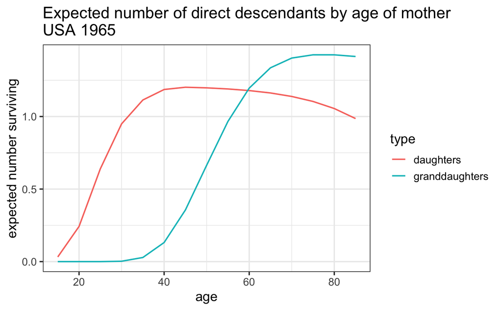

## Summary thoughts

The estimates calculated from WPP are somewhat similar to Goodman et al (pages 5,6). Would be interested to check the functions on the data they actually used to see if it’s alright.